# Step E

2022-11-17

####Data Cleaning

1. Editing column names

```r
countryDat <- read.csv("~/(5) UMN Fall 2022/Advanced R PSY/Semester Coding Project/countryDat.csv")
colnames(countryDat)
```

```
## [1] "Entity"                    "Code"
## [3] "GPI.Ranking"               "Year"
## [5] "Depression...."            "Alcohol.use.disorders...."
## [7] "Drug.use.disorders...."
```

```r
colnames(countryDat)[1]<-"Country"
colnames(countryDat)[3]<-"GPI"
colnames(countryDat)[4]<-"Year"
colnames(countryDat)[5]<-"Depression"
colnames(countryDat)[6]<-"AlcoholUseDisorder"
colnames(countryDat)[7]<-"DrugUseDisorder"
```

2. Defining which countries’ GPIs are considered to be “top”, “middle”, or “bottom”

```r
countryDat$BMT<-NA
```

```r
countryDat$BMT<-ifelse(countryDat$GPI<55, "Top",
                       ifelse(countryDat$GPI>109, "Bottom", "Middle"))
```

####Research Question 1 Do countries that rank in the top, middle, and bottom of the GPI report different rates of depression among their population?

**Null and Alt Hypotheses** Ho1: There will be no difference in the percentage of a country’s population suffering from depression between countries that rank in the top, middle, and bottom by GPI.

Ha1: Countries’ that rank in the top and bottom by GPI will have a significantly higher rate of their population suffering from depression compared to middle ranked countries.

**Analyses**

```r
depressionANOVA<-aov(Depression ~ BMT, data=countryDat)
summary(depressionANOVA)
```

```
##              Df Sum Sq Mean Sq F value Pr(>F)
## BMT           2   0.38  0.1879    0.48   0.62
## Residuals   153  59.94  0.3918
```

We fail to reject the null hypothesis. P-value (0.62)>0.05

**Visualization**

```r
library(Rmisc)
```

```r
library(ggplot2)
countryDat1Mean<-summarySE(countryDat, groupvars="BMT", measurevar="Depression")
countryDat1Mean
```

```
##      BMT  N Depression        sd         se        ci
## 1 Bottom 51   3.558770 0.5504002 0.07707144 0.1548025
## 2 Middle 53   3.440358 0.7154643 0.09827658 0.1972064
## 3    Top 52   3.516589 0.5970448 0.08279522 0.1662183
```

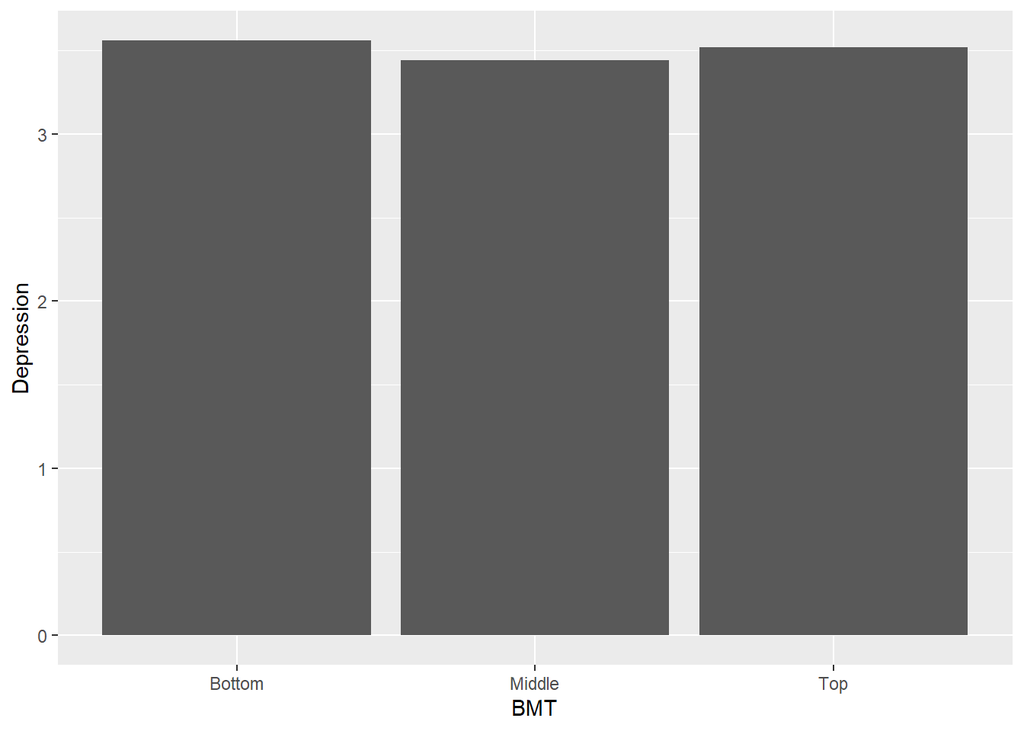

```r
ggplot(countryDat1Mean, aes(BMT,Depression))+geom_bar(stat="identity")
```

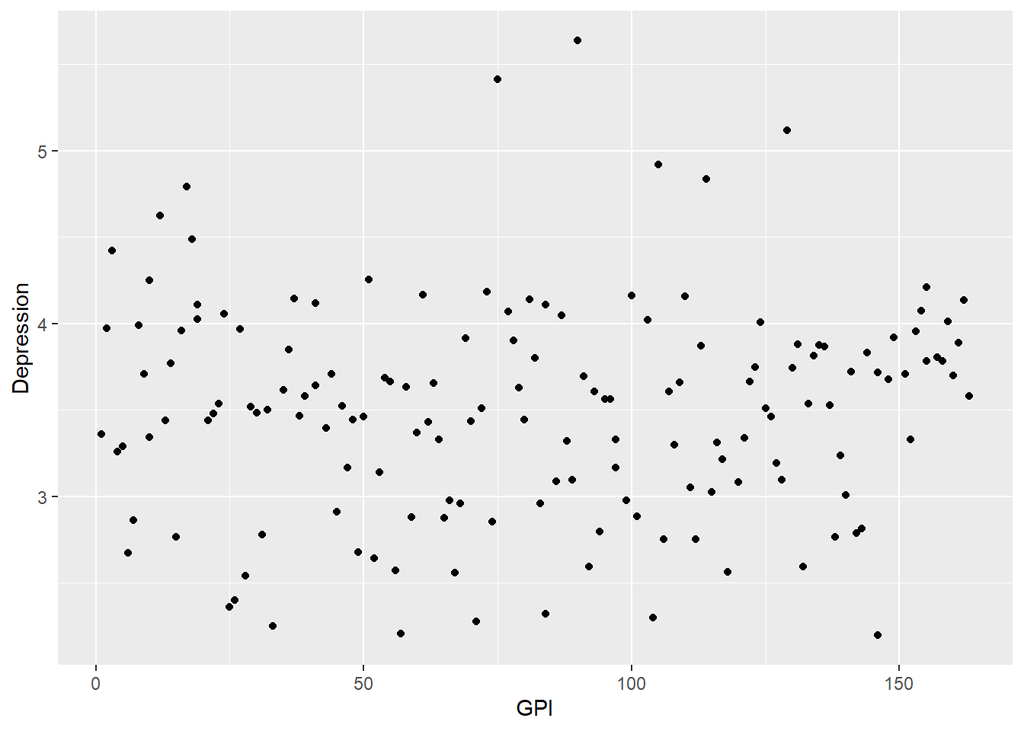

```r
ggplot(countryDat, aes(GPI, Depression))+geom_point()
```

####Research Question 2 Do countries that rank in the top, middle, and bottom of the GPI report different rates of Alcohol Use Disorder among their population?

**Null and Alt Hypotheses** Ho1: There will be no difference in the percentage of a country’s population suffering from Alcohol Use Disorder between countries that rank in the top, middle, and bottom by GPI.

Ha1: Countries’ that rank in the top and bottom by GPI will have a significantly higher rate of their population suffering from Alcohol Use Disorder compared to middle ranked countries.

**Analyses**

```r
alcoholANOVA<-aov(AlcoholUseDisorder ~ BMT, data=countryDat)
summary(alcoholANOVA)
```

```
##              Df Sum Sq Mean Sq F value Pr(>F)
## BMT           2    2.4  1.1996   1.498  0.227
## Residuals   153  122.5  0.8008
```

We fail to reject the null hypothesis. P-value (0.227)>0.05

**Visualization**

```r
countryDat2Mean<-summarySE(countryDat, groupvars="BMT", measurevar="AlcoholUseDisorder")
countryDat2Mean
```

```
##      BMT  N AlcoholUseDisorder        sd        se        ci
## 1 Bottom 51           1.424846 0.8966400 0.1255547 0.2521841
## 2 Middle 53           1.593929 0.8626668 0.1184964 0.2377804
## 3    Top 52           1.729586 0.9248934 0.1282596 0.2574920
```

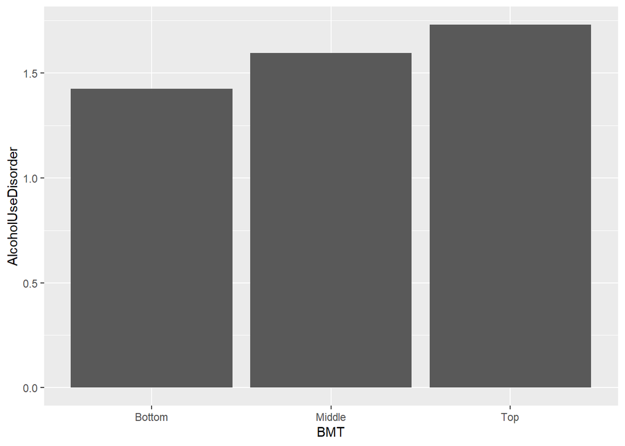

```r
ggplot(countryDat2Mean, aes(BMT,AlcoholUseDisorder))+geom_bar(stat="identity")
```

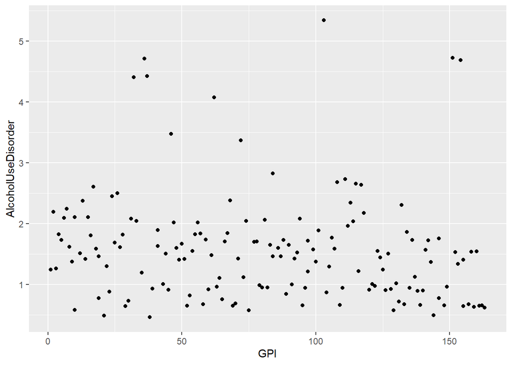

```r
ggplot(countryDat, aes(GPI, AlcoholUseDisorder))+geom_point()
```

####Research Question 3 Do countries that rank in the top, middle, and bottom of the GPI report different rates of Drug Use Disorder among their population?

**Null and Alt Hypotheses** Ho1: There will be no difference in the percentage of a country’s population suffering from Drug Use Disorder between countries that rank in the top, middle, and bottom by GPI.

Ha1: Countries’ that rank in the top and bottom by GPI will have a significantly higher rate of their population suffering from Drug Use Disorder compared to middle ranked countries.

**Analyses**

```r
drugANOVA<-aov(DrugUseDisorder ~ BMT, data=countryDat)
summary(drugANOVA)
```

```
##              Df Sum Sq Mean Sq F value Pr(>F)
## BMT           2   0.81  0.4033   1.415  0.246
## Residuals   153  43.60  0.2850
```

We fail to reject the null hypothesis. P-value (0.246)>0.05

**Visualization**

```r
countryDat3Mean<-summarySE(countryDat, groupvars="BMT", measurevar="DrugUseDisorder")
countryDat3Mean
```

```
##      BMT  N DrugUseDisorder        sd         se        ci
## 1 Bottom 51       0.9465308 0.6687682 0.09364628 0.1880941
## 2 Middle 53       0.7844139 0.4690922 0.06443477 0.1292978
## 3    Top 52       0.9235987 0.4383248 0.06078472 0.1220304
```

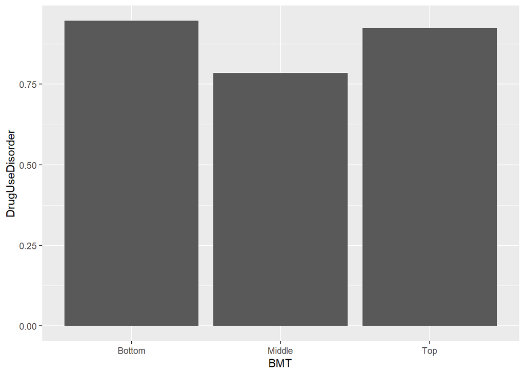

```r
ggplot(countryDat3Mean, aes(BMT,DrugUseDisorder))+geom_bar(stat="identity")
```

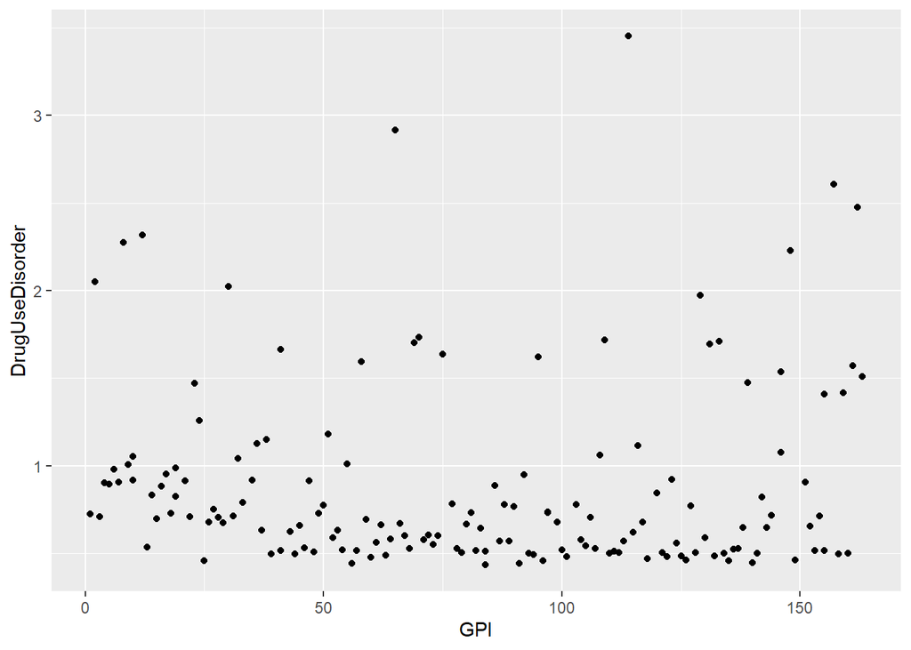

```r
ggplot(countryDat, aes(GPI, DrugUseDisorder))+geom_point()
```

####Next Steps 1. Make sure I did everything right. 2. Make the graphs look pretty. 3. Write conclusions.